# EDA of Four Horses in a Race

150000760

### Executive Summary

The expectation and variance reflects uncertainty to predictions, which is right as gamblers should be uncertain.

Relevant plots are redone in SAS, to prove repeatability, and are attached in a seperate file .

### Introduction

This report analyzes betting exchange data for three randomly chosen horses and the winner. After data cleaning and Exploratory Data Analysis we determine the maximum amount of profit that could be made using an arbitrage position for the winner and the losers.

Backing a horse is betting that that horse will win. Laying a horse is betting that that horse will lose. Given n horses in a race, n-1 of them will lose, so the probability that a horse loses is higher than the probability that a given horse wins. A stake is the amount of money you will place on a bet, which is capped by the total volume in the market.

Odds are the multiple offered on a stake for a given bet, laying or backing. Odds given are intrinsically related to the probability that a certain event will occur. This is because the goal of a fair bet is to make the expected value zero.

## Exploratory Data Analysis

With any dataset, it is good to see summary stats.

```
##       time                     marketStatus         inplay
##  Min.   :2018-06-20 15:29:02   Length:111276      Mode :logical
##  1st Qu.:2018-06-20 15:38:13   Class :character   FALSE:96030
##  Median :2018-06-20 15:48:34   Mode  :character   TRUE :15246
##  Mean   :2018-06-20 15:48:34
##  3rd Qu.:2018-06-20 15:58:43
##  Max.   :2018-06-20 16:08:45
##    competitor       competitorStatus    backPrice1
##  Min.   :  868018   Length:111276      Length:111276
##  1st Qu.: 8864290   Class :character   Class :character
##  Median :11162146   Mode  :character   Mode  :character
##  Mean   :10210545
##  3rd Qu.:11931592
##  Max.   :13373355
##  backVolume1         layPrice1          layVolume1
##  Length:111276      Length:111276      Length:111276
##  Class :character   Class :character   Class :character
##  Mode  :character   Mode  :character   Mode  :character
##
##
##
```

The data is not nice! We would like Price and Volume columns to be numeric so that we may manipulate such calculations.

There is quite a number of NaNs! Can we visualize them?

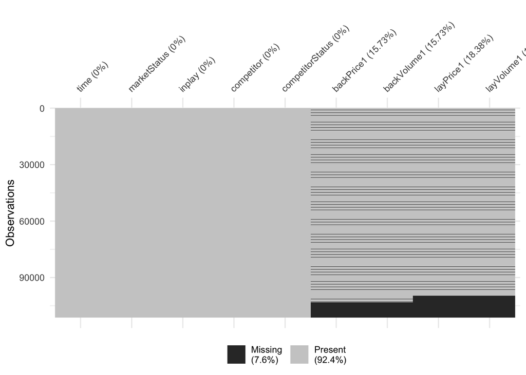

```r
library(naniar)
vis_miss(HorseData, warn_large_data = FALSE)
```

For Ease of analysis, we would like to remove NaN values, but important information - whether the Horse won or lost - is in these columns. A Column is formed of all False Booleans, then the competitor 11473056 with the winning horse is changed to true. It does not matter if you remove the final backPrice1 rows. By that point the horse would have lost anyways, so it would not be possible to lay them.

```r
HorseData$Winner <- FALSE
HorseData$Winner[HorseData$competitor == 11473056] <- TRUE
```

Now the NaNs are removed.

```r
HorseData <- na.omit(HorseData)
```

And finally, two new columns are added for ease of analysis

```r
HorseData$backVP <- HorseData$backPrice1 * HorseData$backVolume1
HorseData$layVP <- HorseData$layPrice1 * HorseData$layVolume1
```

```r
summary(HorseData)
```

```
##       time                     marketStatus         inplay
##  Min.   :2018-06-20 15:29:02   Length:90721       Mode :logical
##  1st Qu.:2018-06-20 15:37:15   Class :character   FALSE:87300
##  Median :2018-06-20 15:46:13   Mode  :character   TRUE :3421
##  Mean   :2018-06-20 15:46:29
##  3rd Qu.:2018-06-20 15:55:34
##  Max.   :2018-06-20 16:04:43
##    competitor       competitorStatus     backPrice1      backVolume1
##  Min.   :  868018   Length:90721       Min.   :  1.03   Min.   :   2.00
##  1st Qu.: 8846010   Class :character   1st Qu.: 19.50   1st Qu.:  33.11
##  Median :11295111   Mode  :character   Median : 29.00   Median :  97.01
##  Mean   :10146425                      Mean   : 64.09   Mean   : 213.11
##  3rd Qu.:11985643                      3rd Qu.: 70.00   3rd Qu.: 226.82
##  Max.   :13373355                      Max.   :670.00   Max.   :4005.50
##    layPrice1         layVolume1        Winner            backVP
##  Min.   :   1.04   Min.   :   2.00   Mode :logical   Min.   :    5.1
##  1st Qu.:  20.00   1st Qu.:  15.25   FALSE:87690     1st Qu.: 1718.9
##  Median :  30.00   Median :  54.16   TRUE :3031      Median : 3928.9
##  Mean   :  72.81   Mean   : 153.06                   Mean   : 5266.9
##  3rd Qu.:  80.00   3rd Qu.: 153.90                   3rd Qu.: 6801.1
##  Max.   :1000.00   Max.   :3063.73                   Max.   :50068.8
##      layVP
##  Min.   :    2.08
##  1st Qu.:  942.54
##  Median : 2256.76
##  Mean   : 4014.92
##  3rd Qu.: 4961.00
##  Max.   :41360.36
```

## Variance and Expectation analysis

```r
unique(HorseData$competitor)
```

```
##  [1] 11817468 11538828  6044572   868018 12886815 10308467 11931592
##  [8] 11473056  8846010 13373355 12666330 12452848 12192132 10058972
## [15] 11314111  5521783  9175949  8565296  8692300 12150386  7579136
## [22]  9748889  9977366  8864290 12886814 11295113 11295111 11985643
## [29]  8528919 10339376
```

```r
sorted_data <- HorseData[order(HorseData$competitor, HorseData$time),]
```

The following three competitors and the winner were randomly chosen (by eyeball not RNG). For ease of data replication, the extracted datasets were exported to CSV.

```r
winner<-sorted_data[which(sorted_data$competitor==11473056), ]
write.csv(winner,"./winner.csv", row.names=FALSE)
competitor2<-sorted_data[which(sorted_data$competitor==11538828), ]
write.csv(competitor2,"./competitor2.csv", row.names=FALSE)
competitor3<-sorted_data[which(sorted_data$competitor==9977366), ]
write.csv(competitor3,"./competitor3.csv", row.names=FALSE)
competitor4<-sorted_data[which(sorted_data$competitor==10339376), ]
write.csv(competitor4,"./competitor4.csv", row.names=FALSE)
```

# Back and Lay odds trace for pre-inplay data.

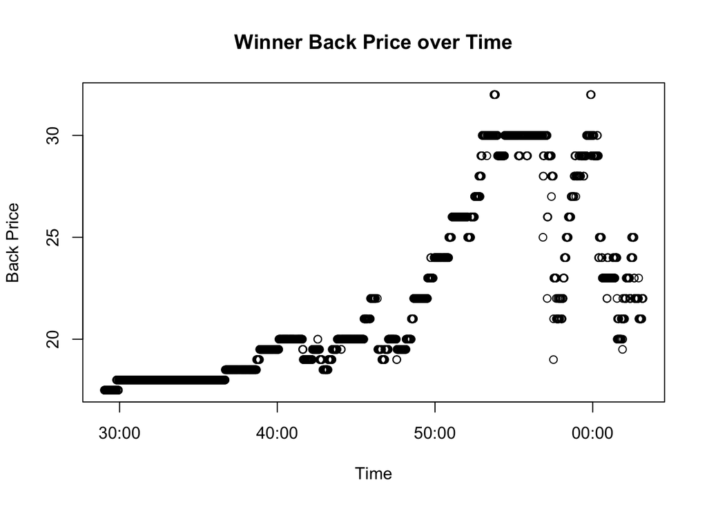

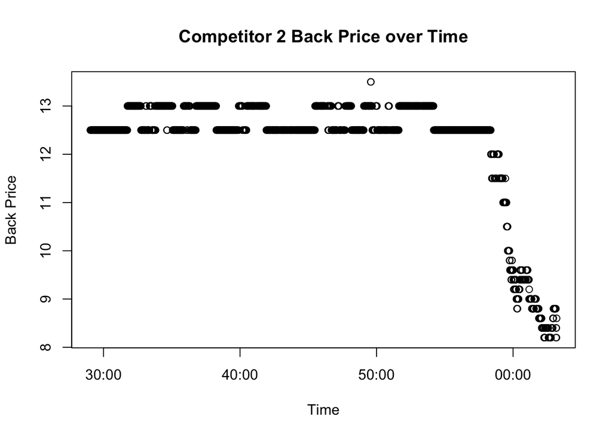

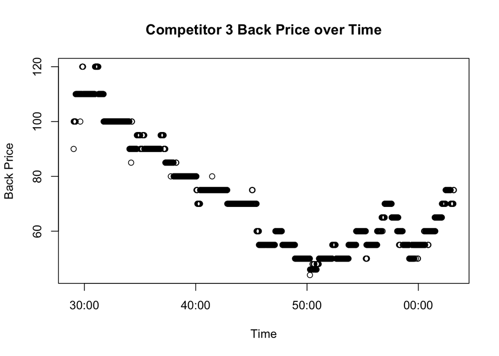

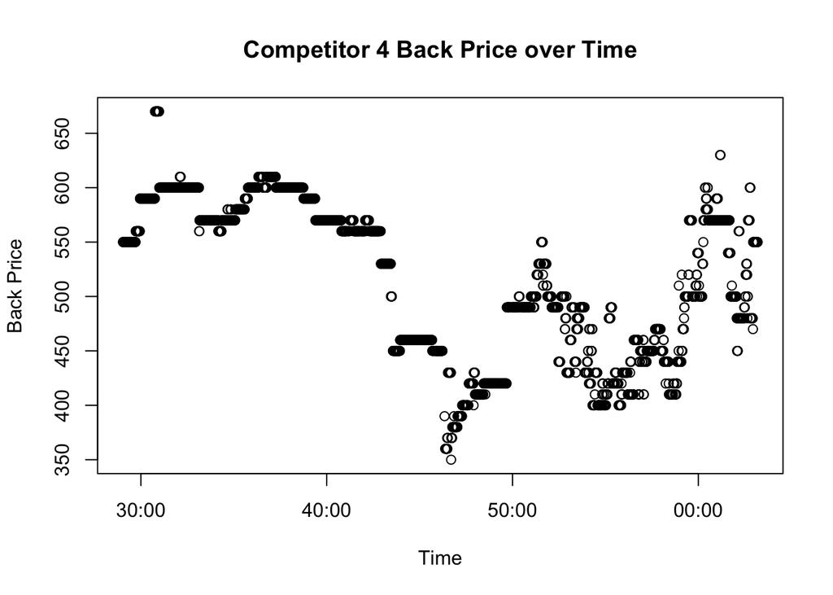

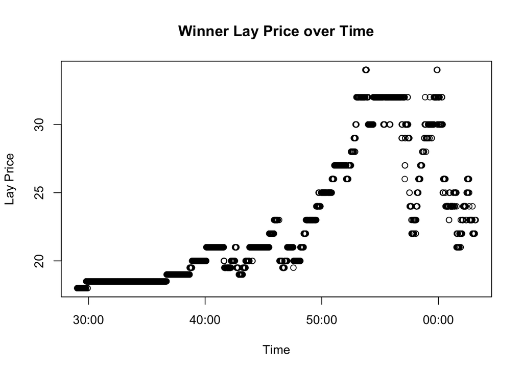

```r
plot(winneroutplay$time,winneroutplay$layPrice1,
     main="Winner Lay Price over Time",
     xlab = "Time",
     ylab = "Lay Price")
```

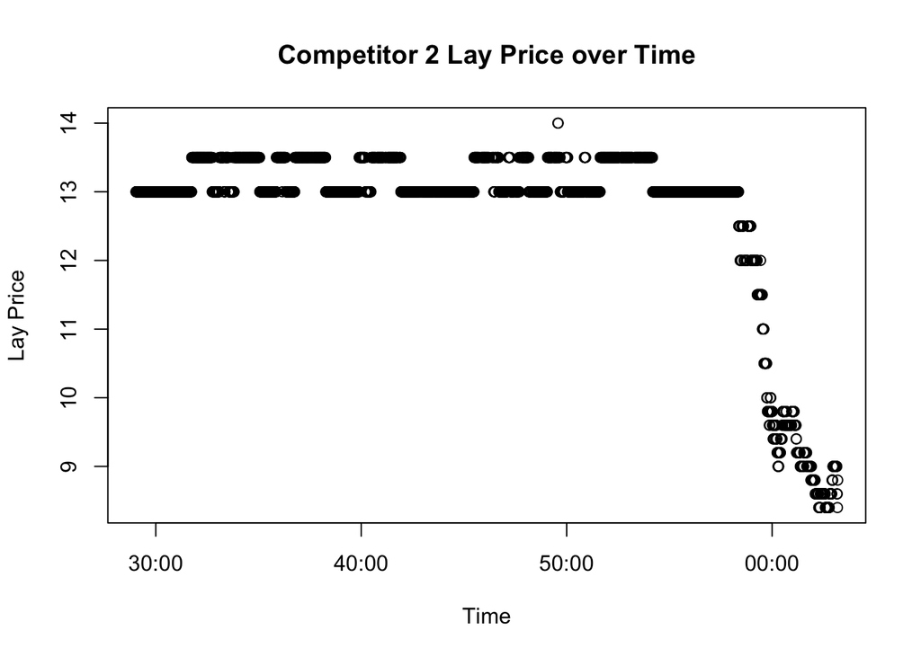

```r
plot(competitor2outplay$time,competitor2outplay$layPrice1,
     main="Competitor 2 Lay Price over Time",
     xlab = "Time",
     ylab = "Lay Price")
```

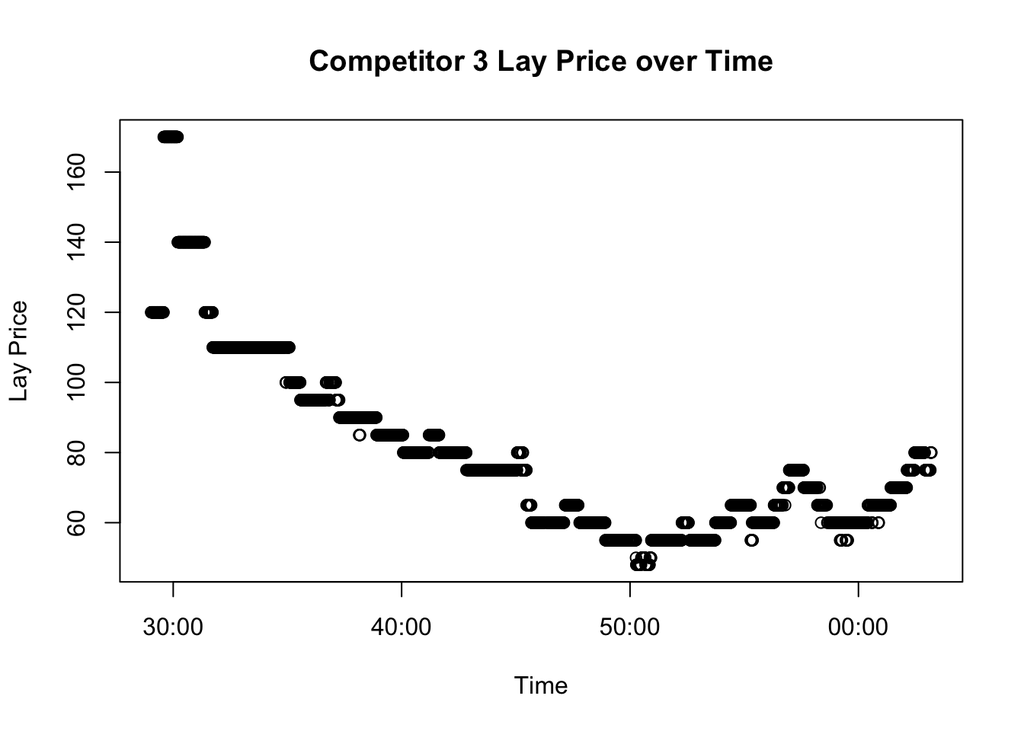

```r
plot(competitor3outplay$time,competitor3outplay$layPrice1,
     main="Competitor 3 Lay Price over Time",
     xlab = "Time",
     ylab = "Lay Price")
```

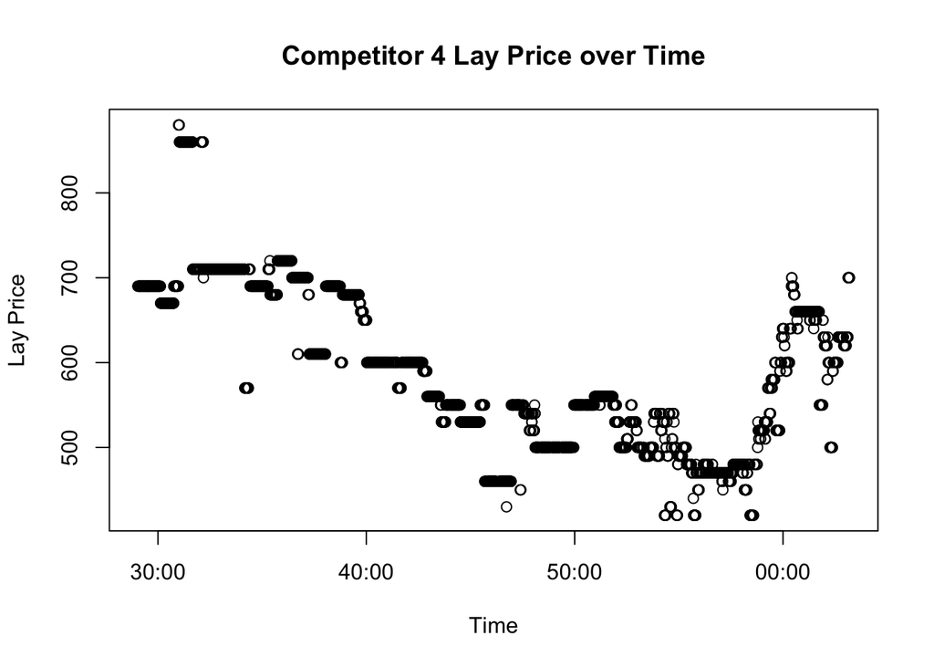

```r
plot(competitor4outplay$time,competitor4outplay$layPrice1,
     main="Competitor 4 Lay Price over Time",
     xlab = "Time",
     ylab = "Lay Price")
```

## Mean/Variance for each player without normalisation.

### Winners mean and variance

```
## [1] "Lay Price Mean"
```

```
## [1] 22.86855
```

```
## [1] "Lay Price Variance"
```

```
## [1] 22.09545
```

```
## [1] "Back Price Mean"
```

```
## [1] 21.93307
```

```
## [1] "Back Price Variance"
```

```
## [1] 18.14569
```

### Competitor 2 mean and variance

```
## [1] "Lay Price Mean"
```

```
## [1] 12.73076
```

```
## [1] "Lay Price Variance"
```

```
## [1] 1.617243
```

```
## [1] "Back Price Mean"
```

```
## [1] 12.25496
```

```
## [1] "Back Price Variance"
```

```
## [1] 1.404177
```

### Competitor 3 mean and variance

```
## [1] "Lay Price Mean"
```

```
## [1] 80.85719
```

```
## [1] "Lay Price Variance"
```

```
## [1] 645.9579
```

```
## [1] "Back Price Mean"
```

```
## [1] 72.61734
```

```
## [1] "Back Price Variance"
```

```
## [1] 370.5275
```

### Competitor 4 mean and variance

```
## [1] "Lay Price Mean"
```

```
## [1] 593.861
```

```
## [1] "Lay Price Variance"
```

```
## [1] 9041.611
```

```
## [1] "Back Price Mean"
```

```
## [1] 517.4535
```

```
## [1] "Back Price Variance"
```

```
## [1] 5015.957
```

## How much money could you have made on the winner?

Here is a plot of volume*price. The maxima reflects the amount of money you could have made if you bought at that specific time, the entire volume.

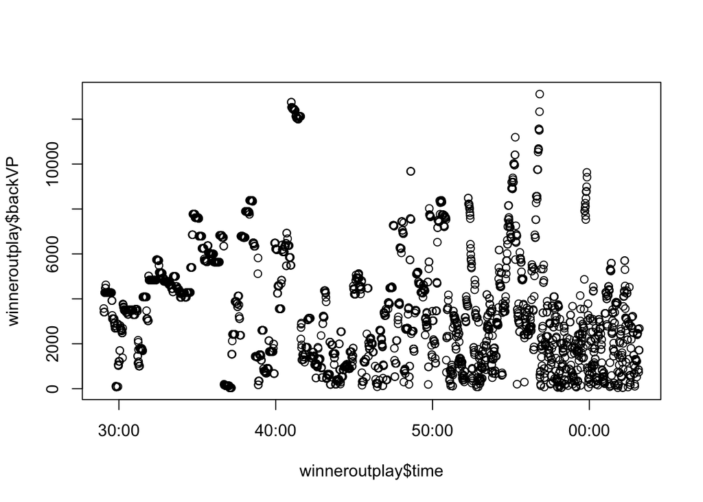

Lets find the maximum vp, the time at which it occured, and the maximum stake size.

```
## [1] 13114.2
```

```
## [1] "2018-06-20 15:56:50 UTC"
```

```
## [1] 437.14
```

```
## [1] 30
```

So 13,114.20 GBP was the maximum you could have made if you backed the winner at 15:56:50 with a 437.14 stake at 30/1 odds.

So could you have found a lay, so that the 437.14 stake would have been recovered if you lost?

```
## [1] 437.775
```

```
## [1] "2018-06-20 15:41:50 UTC"
```

```
## [1] 22.45
```

```
## [1] 19.5
```

If you laid the horse at “2018-06-20 15:41:50 UTC” with a 22.45 GBP stake at 19.5 odds, you would make 437.78 GBP and covered your loss. You are however liable for the remaining 437.78-22.45 = 415.33 GBP if the horse wins.

## Bibliography

Bernoulli Article on Risk https://www.jstor.org/stable/1909829?seq=1#metadata_info_tab_contents

Explained Betting Exchange https://betting.betfair.com/what-is-a-betting-exchange.html

Explains how laying work https://betting.betfair.com/how-to-use-betfair-exchange/beginner-guides/placing-a-lay-bet-010819-51.html